# Abiotic_site_characterization

2024-03-12

# Load Packages, set file paths, read in the data

```r
#Packages
require(sf)
require(cluster)
require(vegan)
require(raster)
require(factoextra)#for plotting biplots
require(MVN) #significance testing
require(mvnormtest) #significance testing

#file paths
root_folder<-'G:/Shared drives/MacrosystemsBiodiversity/subprojects/MSB_landuse/linear_disturbances'



geofolder<-'G:/Shared drives/MacrosystemsBiodiversity/data/neon_spatial/L0'

sitemeta_folder<-'G:/Shared drives/MacrosystemsBiodiversity/data/landuse/L0'

#data read in
domains<-st_read(file.path(geofolder,'NEON_Domains.shp')) #shape files of domains

sites<-st_read(file.path(geofolder,'NEON_Field_Sites.shp')) #shape files of sites

plots<-st_read(file.path(geofolder,'All_NEON_TOS_Plots_v9/All_NEON_TOS_Plot_Centroids_v9.shp')) #shape files of plots

sitemeta<-read.csv(file.path(sitemeta_folder,'NEON_Field_Site_Metadata_20231026.csv')) #meta data about sites - inc. temp/precip

fragstats<-read.csv(file.path(root_folder,'fragstats_metrics/road_metrics.csv')) #habitat fragmentation data
```

Combine the fragmentation data with the other site data

```r
colnames(fragstats)[2]<-'SiteID'

sites3<-merge(fragstats,sites)
```

## First, let’s just characterize the fragmentation across habitats.

### This will allow us to determine which indices best characterize the fragmentation of the sites.

Before we do a cluster analysis and PCA, lets check for multivariate normality

```r
### prep the data
colnames(sitemeta)[2]<-'SiteID'

clustdat<-merge(sites3,sitemeta,by='SiteID')

### check for normality
clustdat3.us<-clustdat[,c(3:7,9)]

mshapiro.test(t(clustdat3.us))
```

```
##
##  Shapiro-Wilk normality test
##
## data:  Z
## W = 0.71676, p-value = 3.357e-08
```

```r
mvn(clustdat3.us,mvnTest='mardia')
```

```
## $multivariateNormality
##              Test        Statistic              p value Result
## 1 Mardia Skewness 144.289246990094 1.00173265453258e-09     NO
## 2 Mardia Kurtosis 2.78550734926106  0.00534440284668558     NO
## 3             MVN             <NA>                 <NA>     NO
##
## $univariateNormality
##               Test            Variable Statistic   p value Normality
## 1 Anderson-Darling     edgedensity        0.3259  0.5123      YES
## 2 Anderson-Darling landscapeshapeindex    1.0362  0.0091      NO
## 3 Anderson-Darling  aggregationindex      0.4409  0.2785      YES
## 4 Anderson-Darling      division          2.6614  <0.001      NO
## 5 Anderson-Darling    patchdensity        0.7366  0.0512      YES
## 6 Anderson-Darling    interspersion       0.3139  0.5345      YES
##
## $Descriptives
##                      n        Mean    Std.Dev      Median       Min        Max
## edgedensity         47 113.4304695 42.4935466 108.2448746 34.309253 216.430485
## landscapeshapeindex 47  18.2840293  8.9580847  17.3795181  3.613821  44.574187
## aggregationindex    47  81.2708162  6.9588814  81.4345538 66.259120  94.627437
## division            47   0.7488474  0.2329424   0.8687363  0.176923   0.989446
## patchdensity        47  21.5362469 13.4398036  19.0775101  1.902998  72.076656
## interspersion       47  51.0207339 12.7590694  51.4878279 23.790305  80.480686
##                           25th        75th        Skew   Kurtosis
## edgedensity         88.1222738 148.4858381  0.11740561 -0.7324914
## landscapeshapeindex 12.2837129  21.7645491  0.88527405  0.3492778
## aggregationindex    75.7051713  85.7322333  0.02323811 -0.9919234
## division             0.5417761   0.9263683 -0.85574127 -0.6053585
## patchdensity        11.0570837  28.8342957  1.09477035  2.0931842
## interspersion       40.6762070  59.4669234 -0.10833688 -0.6621577
```

P values were less than 0.05 - indicates non normality but that is okay. Scale the data then do a cluster analysis

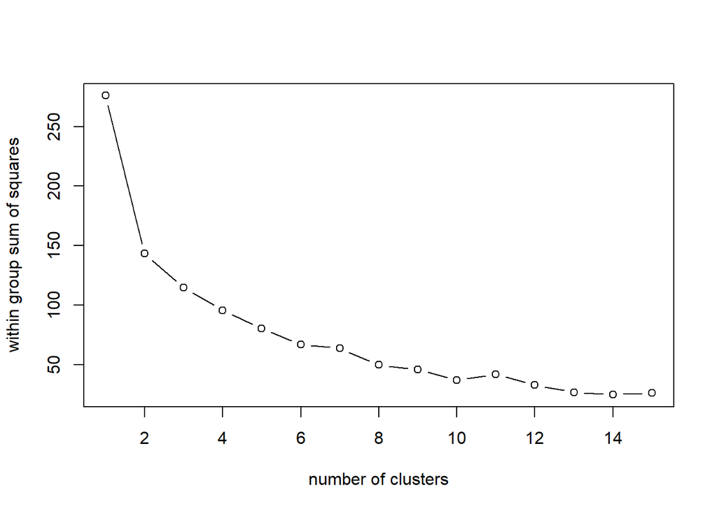

```r
#scale data and add row names
clustdat4<-scale(clustdat3.us)

rownames(clustdat4)<-clustdat$SiteID

#determine the number of clusters
wss<-(nrow(clustdat4)-1)*sum(apply(clustdat4,2,var))

for(i in 2:15){
  wss[i]<-sum(kmeans(clustdat4,center=i)$withinss)
}

plot(1:15,wss,type='b',xlab='number of clusters',ylab='within group sum of squares') #2 clusters probably
```

Do K-means clustering and plot - also MRPP for significance of clusters

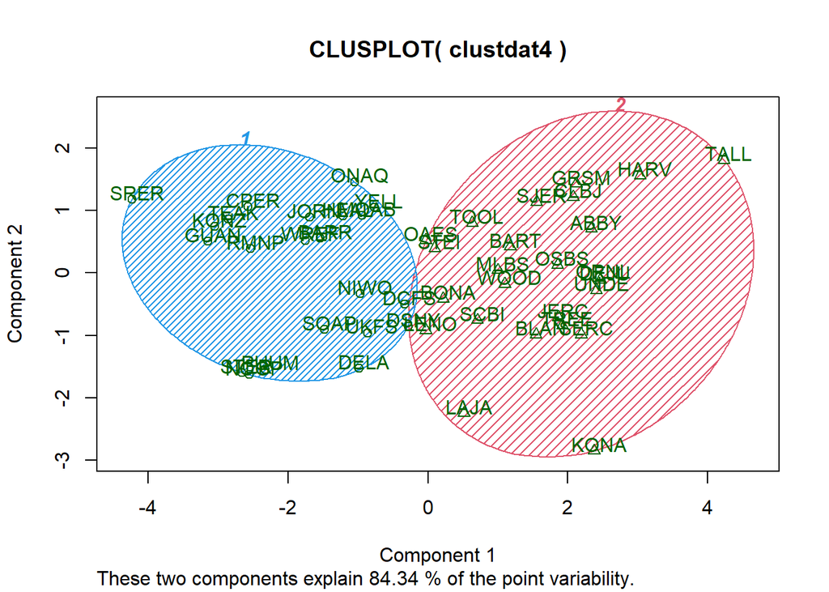

```r
fit2<-kmeans(clustdat4,centers=2,iter.max=10,nstart=25)

clusplot(clustdat4,fit2$cluster,color=T,shade=T,labels=2)
```

```r
## Significance testing
#set up data
frag.groups<-fit2$cluster

frag.dist<-vegdist(clustdat4,method='euclidean')
#do the test
set.seed(11)
fragmrpp<-mrpp(frag.dist,frag.groups,permutations=1000)
fragmrpp
```

```
##
## Call:
## mrpp(dat = frag.dist, grouping = frag.groups, permutations = 1000)
##
## Dissimilarity index: euclidean
## Weights for groups:  n
##
## Class means and counts:
##
##       1     2
## delta  2.33 2.356
## n     22    25
##
## Chance corrected within-group agreement A: 0.2594
## Based on observed delta 2.344 and expected delta 3.165
##
## Significance of delta: 0.000999
## Permutation: free
## Number of permutations: 1000
```

clusters are significant

## Do a PCA on the data and plot - determine which variables drive the clustering

```r
fit2.pc<-princomp(clustdat4,cor=T)
summary(fit2.pc)
```

```
## Importance of components:
##                           Comp.1    Comp.2     Comp.3     Comp.4     Comp.5
## Standard deviation     1.9804541 1.0668476 0.62847633 0.54315722 0.48458020
## Proportion of Variance 0.6536997 0.1896940 0.06583042 0.04916996 0.03913633
## Cumulative Proportion  0.6536997 0.8433937 0.90922411 0.95839407 0.99753040
##                             Comp.6
## Standard deviation     0.121727618
## Proportion of Variance 0.002469602
## Cumulative Proportion  1.000000000
```

```r
fit2.pc$loadings
```

```
##
## Loadings:
##                     Comp.1 Comp.2 Comp.3 Comp.4 Comp.5 Comp.6
## edgedensity          0.468  0.176         0.312  0.547  0.590
## landscapeshapeindex  0.327  0.585 -0.619 -0.125 -0.384
## aggregationindex    -0.489 -0.112        -0.307 -0.197  0.779
## division             0.435         0.434 -0.788
## patchdensity         0.413 -0.377  0.235  0.354 -0.682  0.201
## interspersion        0.275 -0.686 -0.598 -0.215  0.219
##
##                Comp.1 Comp.2 Comp.3 Comp.4 Comp.5 Comp.6
## SS loadings     1.000  1.000  1.000  1.000  1.000  1.000
## Proportion Var  0.167  0.167  0.167  0.167  0.167  0.167
## Cumulative Var  0.167  0.333  0.500  0.667  0.833  1.000
```

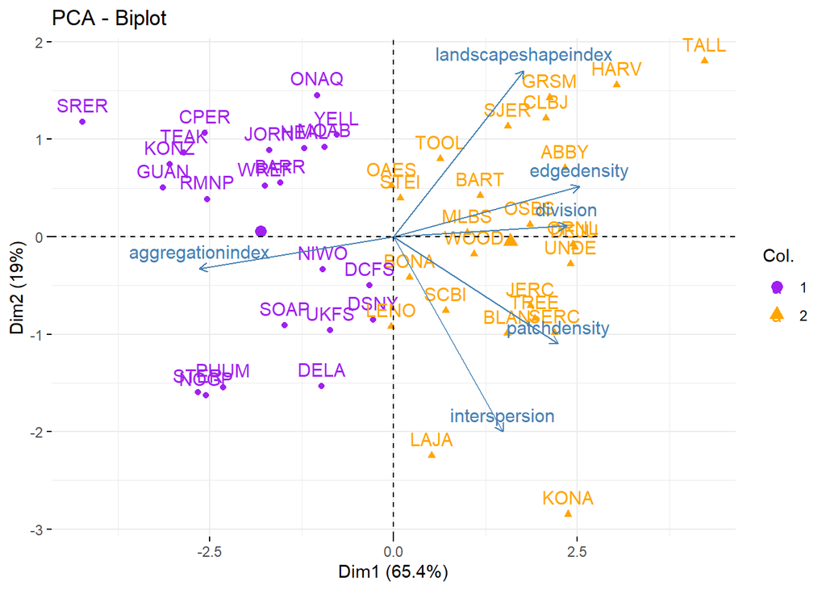

```r
fviz_pca_biplot(fit2.pc,col.ind=as.character(fit2$cluster),palette=c('purple','orange'))
```

Do significance testing on the loadings

```r
#first write a function to do the significane testing - bootstrapping method
sigpca2<-function (x, permutations=1000, ...)
{
  pcnull <- princomp(x, ...)
  res <- pcnull$loadings
  out <- matrix(0, nrow=nrow(res), ncol=ncol(res))
  N <- nrow(x)
  for (i in 1:permutations) {
    pc <- princomp(x[sample(N, replace=TRUE), ], ...)
    pred <- predict(pc, newdata = x)
    r <-  cor(pcnull$scores, pred)
    k <- apply(abs(r), 2, which.max)
    reve <- sign(diag(r[k,]))
    sol <- pc$loadings[ ,k]
    sol <- sweep(sol, 2, reve, "*")
    out <- out + ifelse(res > 0, sol <=  0, sol >= 0)
  }
  out/permutations
}

set.seed(4)

sigpca2(clustdat4, permutations=1000)
```

```
##                     Comp.1 Comp.2 Comp.3 Comp.4 Comp.5 Comp.6
## edgedensity          0.000  0.038  0.325  0.124  0.063  0.000
## landscapeshapeindex  0.001  0.001  0.044  0.411  0.114  0.010
## aggregationindex     0.000  0.058  0.256  0.097  0.148  0.000
## division             0.000  0.325  0.146  0.093  0.600  0.295
## patchdensity         0.000  0.001  0.186  0.267  0.068  0.001
## interspersion        0.001  0.001  0.057  0.351  0.158  0.093
```

All loadings are significant but ‘edge density’ and ‘aggregation index’ drive PC1 the most - use these in the broader characterization

# Do a cluster analysis on more abiotic factors to see the role of habitat fragmentation for driving patterning of sites

## First, test for normality and prep the data

```r
### test for multivariate normality
clustdat2.us<-clustdat[,c(3,5,40,43,44)] #chose only the fragmentation metrics with the highest loadings on PC 1 from the previous analysis

mshapiro.test(t(clustdat2.us)) #pvalue less than 0.5
```

```
##
##  Shapiro-Wilk normality test
##
## data:  Z
## W = 0.80866, p-value = 2.495e-06
```

```r
mvn(clustdat2.us,mvnTest='mardia') #pvalue less than 0.5 - elevation and precip are the belligerents
```

```
## $multivariateNormality
##              Test        Statistic              p value Result
## 1 Mardia Skewness 118.148753598082 6.00211262484222e-11     NO
## 2 Mardia Kurtosis 2.79550703353203  0.00518183742266642     NO
## 3             MVN             <NA>                 <NA>     NO
##
## $univariateNormality
##               Test                           Variable Statistic   p value
## 1 Anderson-Darling            edgedensity                0.3259  0.5123
## 2 Anderson-Darling          aggregationindex             0.4409  0.2785
## 3 Anderson-Darling       field_mean_elevation_m          3.0584  <0.001
## 4 Anderson-Darling  field_mean_annual_temperature_C      0.3075  0.5491
## 5 Anderson-Darling field_mean_annual_precipitation_mm    1.1394   0.005
##   Normality
## 1    YES
## 2    YES
## 3    NO
## 4    YES
## 5    NO
##
## $Descriptives
##                                     n      Mean    Std.Dev    Median       Min
## edgedensity                        47 113.43047  42.493547 108.24487  34.30925
## aggregationindex                   47  81.27082   6.958881  81.43455  66.25912
## field_mean_elevation_m             47 731.74468 779.110933 467.00000   4.00000
## field_mean_annual_temperature_C    47  10.03191   8.005273  10.10000 -12.00000
## field_mean_annual_precipitation_mm 47 917.82979 555.878596 850.00000 105.00000
##                                           Max      25th       75th        Skew
## edgedensity                         216.43049  88.12227  148.48584  0.11740561
## aggregationindex                     94.62744  75.70517   85.73223  0.02323811
## field_mean_elevation_m             3490.00000 251.00000 1083.50000  1.56491403
## field_mean_annual_temperature_C      25.00000   4.90000   15.60000 -0.53922963
## field_mean_annual_precipitation_mm 2657.00000 473.50000 1225.00000  1.09349028
##                                      Kurtosis
## edgedensity                        -0.7324914
## aggregationindex                   -0.9919234
## field_mean_elevation_m              2.1248292
## field_mean_annual_temperature_C     0.1491888
## field_mean_annual_precipitation_mm  1.4089671
```

```r
#log transform elevation
#log transform precip

clustdat2.us$field_mean_annual_precipitation_mm<-log(clustdat2.us$field_mean_annual_precipitation_mm)
clustdat2.us$field_mean_elevation_m<-log(clustdat2.us$field_mean_elevation_m)

#try tests for normality again

mshapiro.test(t(clustdat2.us)) #p < 0.05
```

```
##
##  Shapiro-Wilk normality test
##
## data:  Z
## W = 0.73058, p-value = 6.036e-08
```

```r
mvn(clustdat2.us,mvnTest='mardia') #p < 0.05, elevation and precip still not normal in univariate space either
```

```
## $multivariateNormality
##              Test        Statistic              p value Result
## 1 Mardia Skewness  134.94209576071 1.16053544765557e-13     NO
## 2 Mardia Kurtosis 4.09492542765199 4.22304293208331e-05     NO
## 3             MVN             <NA>                 <NA>     NO
##
## $univariateNormality
##               Test                           Variable Statistic   p value
## 1 Anderson-Darling            edgedensity                0.3259    0.5123
## 2 Anderson-Darling          aggregationindex             0.4409    0.2785
## 3 Anderson-Darling       field_mean_elevation_m          1.5713    0.0004
## 4 Anderson-Darling  field_mean_annual_temperature_C      0.3075    0.5491
## 5 Anderson-Darling field_mean_annual_precipitation_mm    0.9526    0.0147
##   Normality
## 1    YES
## 2    YES
## 3    NO
## 4    YES
## 5    NO
##
## $Descriptives
##                                     n       Mean    Std.Dev     Median
## edgedensity                        47 113.430469 42.4935466 108.244875
## aggregationindex                   47  81.270816  6.9588814  81.434554
## field_mean_elevation_m             47   5.855824  1.5343468   6.146329
## field_mean_annual_temperature_C    47  10.031915  8.0052729  10.100000
## field_mean_annual_precipitation_mm 47   6.628268  0.6693053   6.745236
##                                           Min        Max      25th       75th
## edgedensity                         34.309253 216.430485 88.122274 148.485838
## aggregationindex                    66.259120  94.627437 75.705171  85.732233
## field_mean_elevation_m               1.386294   8.157657  5.521941   6.984755
## field_mean_annual_temperature_C    -12.000000  25.000000  4.900000  15.600000
## field_mean_annual_precipitation_mm   4.653960   7.884953  6.159544   7.110695
##                                           Skew    Kurtosis
## edgedensity                         0.11740561 -0.73249136
## aggregationindex                    0.02323811 -0.99192339
## field_mean_elevation_m             -0.98470952  0.43192512
## field_mean_annual_temperature_C    -0.53922963  0.14918883
## field_mean_annual_precipitation_mm -0.54857690  0.01336614
```

```r
#standardize columns to use in cluster analysis

clustdat2<-scale(clustdat[,c(3,5,40,43,44)]) #edge density and aggregation index for fragmentation - strongest PC1 variables from analysis below

rownames(clustdat2)<-clustdat$SiteID
```

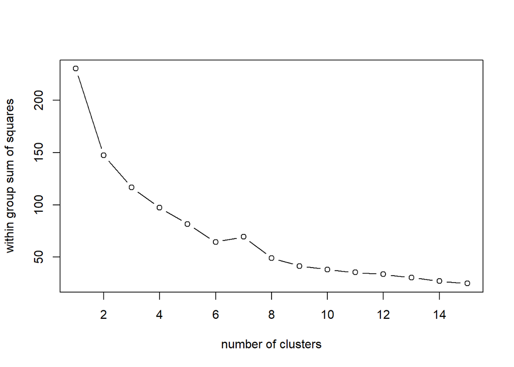

```r
wss<-(nrow(clustdat2)-1)*sum(apply(clustdat2,2,var))

for(i in 2:15){
  wss[i]<-sum(kmeans(clustdat2,center=i)$withinss)
}

plot(1:15,wss,type='b',xlab='number of clusters',ylab='within group sum of squares') #looks like 2 clusters
```

## Do k-means clustering, test significance of clusters, then run a PCA on the data, same as before

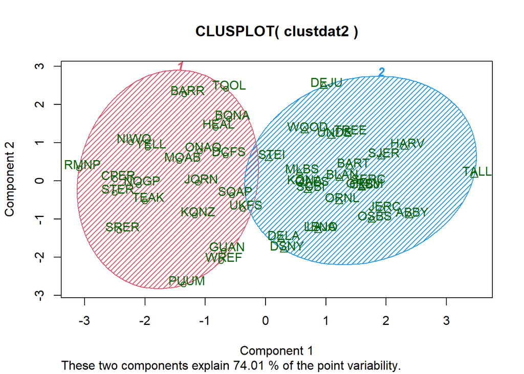

```r
#cluster analysis
fit1<-kmeans(clustdat2,centers=2,iter.max=10,nstart=25)
clusplot(clustdat2,fit1$cluster,color=T,shade=T,labels=2)
```

```r
#significance of clusters
envir.groups<-fit1$cluster

envir.dist<-vegdist(clustdat2,method='euclidean')
set.seed(11)
envirmrpp<-mrpp(envir.dist,envir.groups,permutations=1000)
envirmrpp
```

```
##
## Call:
## mrpp(dat = envir.dist, grouping = envir.groups, permutations = 1000)
##
## Dissimilarity index: euclidean
## Weights for groups:  n
##
## Class means and counts:
##
##       1     2
## delta 2.774 1.957
## n     22    25
##
## Chance corrected within-group agreement A: 0.2002
## Based on observed delta 2.339 and expected delta 2.925
##
## Significance of delta: 0.000999
## Permutation: free
## Number of permutations: 1000
```

```r
#PCA + significance testing of loadings
fit1.pc<-princomp(clustdat2)
summary(fit1.pc)
```

```
## Importance of components:
##                           Comp.1    Comp.2    Comp.3    Comp.4      Comp.5
## Standard deviation     1.5276271 1.1349848 0.8682687 0.6999691 0.167137599
## Proportion of Variance 0.4768752 0.2632389 0.1540559 0.1001216 0.005708452
## Cumulative Proportion  0.4768752 0.7401141 0.8941700 0.9942915 1.000000000
```

```r
fit1.pc$loadings
```

```
##
## Loadings:
##                                    Comp.1 Comp.2 Comp.3 Comp.4 Comp.5
## edgedensity                         0.588  0.288  0.159  0.255  0.693
## aggregationindex                   -0.593 -0.299 -0.159 -0.144  0.716
## field_mean_elevation_m             -0.441  0.128  0.668  0.584
## field_mean_annual_temperature_C     0.210 -0.698 -0.277  0.624
## field_mean_annual_precipitation_mm  0.253 -0.569  0.653 -0.429
##
##                Comp.1 Comp.2 Comp.3 Comp.4 Comp.5
## SS loadings       1.0    1.0    1.0    1.0    1.0
## Proportion Var    0.2    0.2    0.2    0.2    0.2
## Cumulative Var    0.2    0.4    0.6    0.8    1.0
```

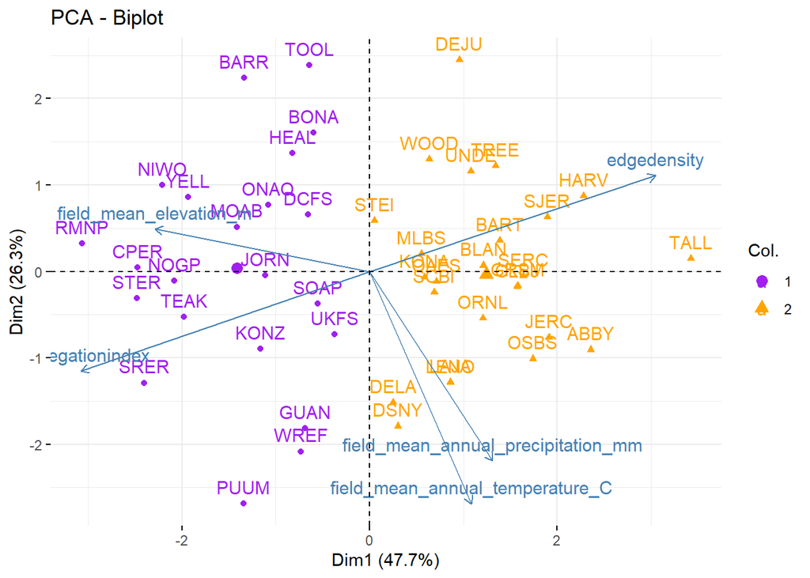

```r
fviz_pca_biplot(fit1.pc,col.ind=as.character(fit1$cluster),palette=c('purple','orange'))
```

```r
set.seed(4)

sigpca2(clustdat4, permutations=1000)
```

```
##                     Comp.1 Comp.2 Comp.3 Comp.4 Comp.5 Comp.6
## edgedensity          0.000  0.038  0.325  0.124  0.063  0.000
## landscapeshapeindex  0.001  0.001  0.044  0.411  0.114  0.010
## aggregationindex     0.000  0.058  0.256  0.097  0.148  0.000
## division             0.000  0.325  0.146  0.093  0.600  0.295
## patchdensity         0.000  0.001  0.186  0.267  0.068  0.001
## interspersion        0.001  0.001  0.057  0.351  0.158  0.093
```

Temperature and precipitation are orthogonal to habitat fragmentation - this decoupling has some important implications. For example, biotic patterns not explained by temp/precip at these sites might instead be driven by fragmentation.